# Week 3 Project

## Nicola Morrow

Compiled on Thu Feb 16 03:38:43 2017.

## Deconstructing graphics

This is a density plot.

The variables in these graphs include: sex, body mass index, and pregnancy status.

The sex variable is indicated by color and shows the difference in BMI between males and females. Body mass index is indicated by position along the x axis. Pregnancy status helps show the difference in BMI between pregnant and non-pregnant people, and is indicated by facet.

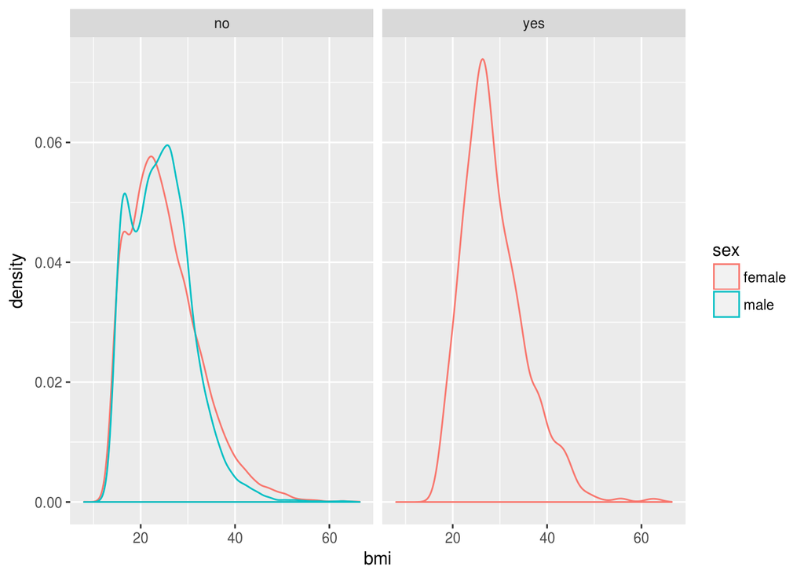

```r
ggplot(data = NCHS, aes(x = bmi)) + geom_density(aes(color = sex)) + facet_wrap(~ pregnant)
```

## Diamonds

### 1

```r
data("diamonds")

diamonds %>%
  group_by( color ) %>%
  summarise( average=mean(carat) ) %>%
  arrange(desc( average )) %>%
  head( 10 )
```

```
## # A tibble: 7 × 2
##   color   average
##   <ord>     <dbl>
## 1     J 1.1621368
## 2     I 1.0269273
## 3     H 0.9117991
## 4     G 0.7711902
## 5     F 0.7365385
## 6     E 0.6578667
## 7     D 0.6577948
```

Diamonds of the color “J” (worst) seem to be the largest.

### 2

```r
diamonds %>%
  group_by( clarity ) %>%
  summarise( average=mean(table) ) %>%
  arrange(desc( average )) %>%
  head( 10 )
```

```
## # A tibble: 8 × 2
##   clarity  average
##     <ord>    <dbl>
## 1      I1 58.30378
## 2     SI2 57.92718
## 3     SI1 57.66254
## 4     VS2 57.41740
## 5     VS1 57.31515
## 6    VVS2 57.02499
## 7    VVS1 56.88446
## 8      IF 56.50721
```

Diamonds of the clarity “I1” (worst) seem to have the largest average table.

## Voting

### 1

```r
data(Minneapolis2013)

tally(Minneapolis2013)
```

```
##       n
## 1 80101
```

There are 80,101 cases.

### 2

```r
Minneapolis2013 %>%
  group_by(Second) %>%
  tally() %>%
  arrange(desc(n)) %>%
  head(5)
```

```
## # A tibble: 5 × 2
##               Second     n
##                <chr> <int>
## 1       BETSY HODGES 14399
## 2        DON SAMUELS 14170
## 3        MARK ANDREW 12757
## 4          undervote 10598
## 5 JACKIE CHERRYHOMES  6470
```

### 3

```r
Minneapolis2013 %>%
  filter(First=="undervote") %>%
  tally()
```

```
##     n
## 1 834
```

There were 834 ballots marked “undervote” in First choice selections.

```r
Minneapolis2013 %>%
  filter(Second=="undervote") %>%
  tally()
```

```
##       n
## 1 10598
```

There were 10,598 ballots marked “undervote” in Second choice selections.

```r
Minneapolis2013 %>%
  filter(Third=="undervote") %>%
  tally()
```

```
##       n
## 1 19210
```

There were 19,210 ballots marked “udnervote”in Third choice selections.

### 4

```r
Minneapolis2013 %>%
  filter(First=="BETSY HODGES") %>%
  group_by(Second) %>%
  summarise(topSecond=n()) %>%
  arrange(desc(topSecond)) %>%
  head(3)
```

```
## # A tibble: 3 × 2
##               Second topSecond
##                <chr>     <int>
## 1        MARK ANDREW      8787
## 2        DON SAMUELS      8743
## 3 JACKIE CHERRYHOMES      2563
```

### 5

```r
Minneapolis2013 %>%
  group_by(Precinct) %>%
  summarise(fraction=mean(First=="undervote")) %>%
  arrange(desc(fraction)) %>%
    head(1)
```

```
## # A tibble: 1 × 2
##   Precinct   fraction
##      <chr>      <dbl>
## 1     P-6C 0.07738095
```